# Lab #2

## Theory

Small standard deviation

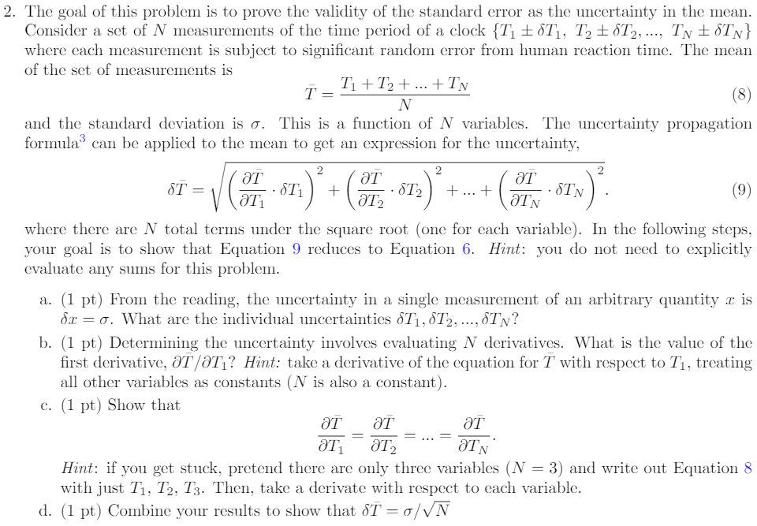

a. Considering that the system we're dealing with is a singular clock, each $\delta T_i$ should be the same standard deviation $\sigma$ in clock measurement.

b. $$\frac{\partial \bar T}{\partial T_1} = \frac{d}{dT_1}\frac{T_1}{N} = \frac{1}{N}$$

c. This is simple. Since $\bar T$ is just the sum of each term divided by $N$, each term has the same shape/operation to compute the partial derivative $$\frac{\partial \bar T}{\partial T_i} = \frac{d}{dT_i}\frac{T_i}{N} = \frac{1}{N} $$

d. Using the above formula $$ \delta \bar T = \sqrt{\left(\frac{1}{N} \sigma \right)^2 + \left(\frac{1}{N} \sigma \right)^2 + \dots + \left(\frac{1}{N} \sigma \right)^2} \\ = \sqrt{\frac{\sigma^2}{N^2} + \frac{\sigma^2}{N^2} + \dots + \frac{\sigma^2}{N^2}} \\ = \sqrt{N\frac{\sigma^2}{N^2}} = \sqrt{\frac{\sigma^2}{N}} = \frac{\sigma}{\sqrt{N}} $$

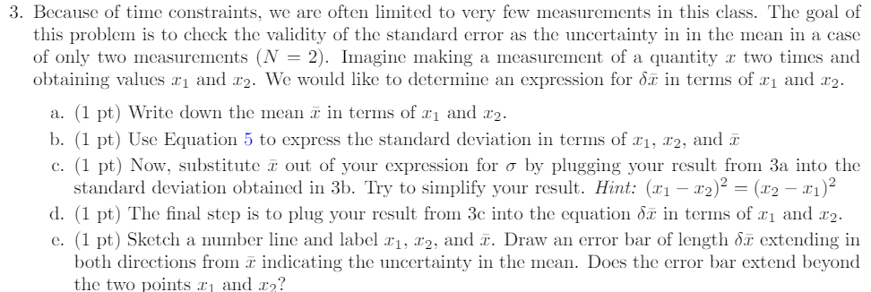

a. Since $N=2$: $$\bar x = \frac{x_1+x_2}{2}$$

b. Equation 5: $$ \sigma = \sqrt{\frac{1}{1} \sum_{i=1}{2}(x_i-\bar x)^2 }\\ = \sqrt{(x_1-\bar x)^2 + (x_2-\bar x)^2}$$

c. $$ \sigma = \sqrt{\left(x_1-\frac{x_1+x_2}{2}\right)^2 + \left(x_2-\frac{x_1+x_2}{2}\right)^2} \\ = \sqrt{\left(\frac{x_1-x_2}{2}\right)^2 + \left(\frac{x_2-x_1}{2}\right)^2} \\ = \sqrt{2\left(\frac{x_1-x_2}{2}\right)^2 } = \frac{\sqrt{2}}{2} \left|x_1-x_2\right| $$

d.

$$ \delta \bar x = \frac{\sigma}{\sqrt{2}} = \frac{1}{2} \left| x_1 - x_2 \right| $$

e.

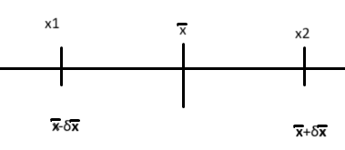

The error bar's ends coincide with the values $x_1$ and $x_2$

## Lab

2. The Clock Experiment

Introduction

This experiment shows the difference between systematic error and random error by allowing participants to use common experimental methods to mitigate random error. Participants make several timing measurements that rely on human reaction time to accurately measure a counter’s counting rate.

Observation

Before doing any measurements, the counter appears to be running a bit faster than one per second. My initial guess for random error (my own reaction time) is ~0.2 seconds.

3. Measurements

Our measurement data was loaded into a numpy array `measured_times` (see below)

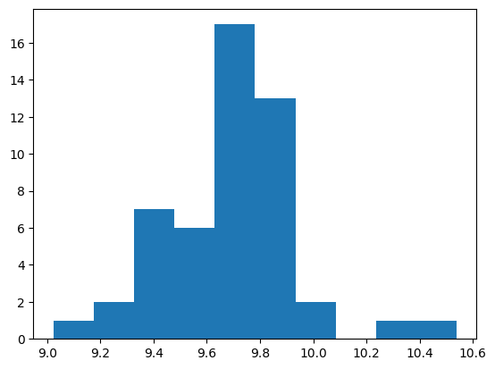

```python
import matplotlib.pyplot as plt
import numpy as np

#recorded time in seconds
measured_times = np.array([
    9.267,9.863,9.391,9.869,
    9.703,10.025,9.441,9.852,
    9.417,9.659,9.435,9.675,
    9.851,9.776,10.023,9.895,
    9.666,9.781,9.407,9.531,
    9.871,9.349,9.792,9.744,
    9.267,9.768,9.896,9.794,
    9.724,9.599,9.024,10.539,
    9.352,9.749,9.591,9.826,
    9.887,10.273,9.613,9.657,
    9.481,9.839,9.652,9.714,
    9.656,9.525,9.817,9.724,
    9.657,9.667])

plt.hist(measured_times)
```

4. Data Analysis

2 Our mean and standard deviaton end up being 9.691 and 0.2527, respectively.

```python
print(f'mean: {measured_times.mean()} sec')
print(f'standard deviation: {measured_times.std():.3f} sec')
```

```
mean: 9.691479999999999 sec
standard deviation: 0.253 sec
```

The uncertainty of the mean is found using the formula $\frac{\sigma}{\sqrt{N}}$, which is $0.0357$ seconds

```python
print(f'standard error: {measured_times.std()/np.sqrt(len(measured_times)):.6f} sec')
```

```
standard error: 0.035740 sec
```

As such, we apply our sig fig rules and report a standard error of $0.04$ and mean of $9.69$

3 My best estimate of the actual mean is $9.69\pm0.04$

4, 5, 6 see plots below. I expect $\bar T$ and $\sigma$ to zig zag and eventually become equal to the final values I calculated above. I expect $\delta \bar T$ to decrease as $N$ increases.

Also, why sketch the graph when I can plot it all! (see below)

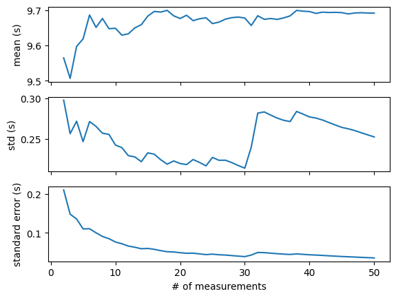

```python
current_mean = []
current_std = []
current_st_err = []

for i, result in enumerate(measured_times):
    current_mean.append(measured_times[:i+1].mean())
    current_std.append(measured_times[:i+1].std())
    current_st_err.append(measured_times[:i+1].std()/np.sqrt(i+1))

fig, axs = plt.subplots(3, 1, sharex=True)
axs[0].plot(range(2, 51), current_mean[1:])
axs[0].set_ylabel('mean (s)')

axs[1].plot(range(2, 51), current_std[1:])
axs[1].set_ylabel('std (s)')

axs[2].plot(range(2, 51), current_st_err[1:])
axs[2].set_xlabel('# of measurements')
axs[2].set_ylabel('standard error (s)')

plt.show()
```

7 See table below

```python
import pandas as pd

N = [3, 5, 10, 20, 30, 40, 50]

df = pd.DataFrame(columns=['N', 'T(s)', 'std (s)', 'dT(s)'])


for i in N:

    dmean = f'{current_st_err[i-1]:.1g}'
    mean = f'{round(current_mean[i-1], len(dmean)-2)}'

    std = f'{current_std[i-1]:.3f}'

    df.loc[len(df)] = [str(i), mean, std, dmean]

df
```

|  | N | T(s) | std (s) | dT(s) |
| --- | --- | --- | --- | --- |
| 0 | 3 | 9.5 | 0.257 | 0.1 |
| 1 | 5 | 9.6 | 0.247 | 0.1 |
| 2 | 10 | 9.65 | 0.243 | 0.08 |
| 3 | 20 | 9.68 | 0.220 | 0.05 |
| 4 | 30 | 9.68 | 0.214 | 0.04 |
| 5 | 40 | 9.7 | 0.277 | 0.04 |
| 6 | 50 | 9.69 | 0.253 | 0.04 |

8 Scatter plot

Kind of made redundant, but here it is:

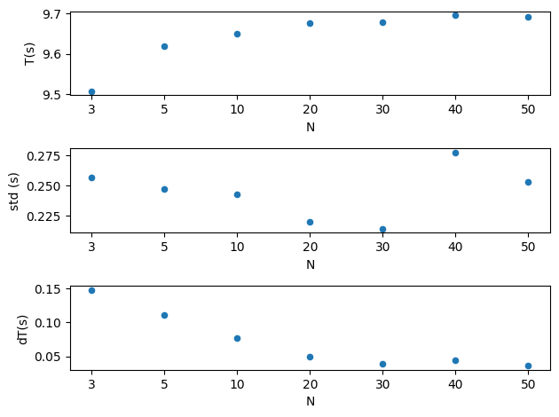

```python
df = pd.DataFrame(columns=['N', 'T(s)', 'std (s)', 'dT(s)'])

for i in N:
    dmean = current_st_err[i-1]
    mean = current_mean[i-1]
    std = current_std[i-1]
    df.loc[len(df)] = [str(i), mean, std, dmean]

fig, axs = plt.subplots(3, 1)
for i, col in enumerate(df.columns[1:]):
    df.plot(x='N', y=col, kind='scatter', ax=axs[i])

plt.tight_layout()
```

9 This is what I described above

5. Drawing Conclusions

1 Count rate estimate

We should be able to simply divide our mean time by $10$ to get our sec/count.

$$\frac{9.69}{10} = 0.969 \text{ sec/count} $$

```python
measured_1_count = measured_times / 10
measured_1_count.std()
```

```
0.025272010129785884
```

```python
measured_1_count.std() / np.sqrt(len(measured_1_count))
```

```
0.003574001947397344
```

Our resulting mean is $0.969 \pm 0.004$. The relative error is the same, which makes sense since our measurements are the same

2 t-test

$$ t = \frac{|R_{ref}-\bar R}{\delta \bar R} = \frac{1-0.969}{0.004} \\= \frac{0.031}{0.004} = 7.75 $$

3 Our results indicate that the clock has a systematic error, and a large one. It is not likely that one count is one second